# Machien Learning - Regression

Daria Ivanushenko

6/2/2021

## **Data Preparation**

**Columns:**

- **id** - Notice identifier. It is not unique: if the notification is updated by the real estate agency (new version of the notification) a new record is created with the same id but different dates: registration and cancellation
- **operation_type** - Type of operation (these are all sales, can be removed)
- **l2** - Administrative level 2: usually province
- **l3** - Administrative level 3: usually city
- **lat** - Latitude
- **lon** - Longitude
- **price** - Price published in the ad
- **property_type** - Type of property (House, Apartment, PH)
- **rooms** - Number of rooms (useful in Argentina)
- **bathrooms** - Number of bathrooms
- **start_date** - Date when the ad was created
- **end_date** - Date of termination of the advertisement
- **created_on** - Date when the first version of the notice was created
- **surface_total** - Total area in m²
- **surface_covered** - Covered area in m²
- **title** - Title of the advertisement
- **description** - Description of the advertisement
- **ad_type** - Type of ad (Property, Development/Project)

Main goal of the analysis is to predict property prices in Argentina

l1 variable has 4 levels hence data should be filtered to Argentina countries only and to properties that for selling excluding ones to rent due to the incomparable prices.

```r
library(readr)
library(dplyr)
setwd("C:\\Users\\daria\\OneDrive\\Desktop\\datasets\\data for R project")

# loading data sets for Argentina, Peru and Uruguay
ar = read.csv("ar_properties.csv", header = TRUE, dec = ".")

ar = ar %>% filter(l1 == "Argentina" & operation_type == "Venta")

ar = ar %>% select(-operation_type, -l1)
```

Dataset has 757534 observations and 23 variables.

```r
library(skimr)
colnames(ar)
```

```
##  [1] "id"              "ad_type"         "start_date"      "end_date"
##  [5] "created_on"      "lat"             "lon"             "l2"
##  [9] "l3"              "l4"              "l5"              "l6"
## [13] "rooms"           "bedrooms"        "bathrooms"       "surface_total"
## [17] "surface_covered" "price"           "currency"        "price_period"
## [21] "title"           "description"     "property_type"
```

```r
summary(ar)
```

```
##       id              ad_type           start_date          end_date
##  Length:757534      Length:757534      Length:757534      Length:757534
##  Class :character   Class :character   Class :character   Class :character
##  Mode  :character   Mode  :character   Mode  :character   Mode  :character
##
##
##
##
##   created_on             lat              lon               l2
##  Length:757534      Min.   :-54.83   Min.   :-180.00   Length:757534
##  Class :character   1st Qu.:-34.96   1st Qu.: -58.74   Class :character
##  Mode  :character   Median :-34.62   Median : -58.44   Mode  :character
##                     Mean   :-34.96   Mean   : -59.21
##                     3rd Qu.:-34.50   3rd Qu.: -58.02
##                     Max.   : 85.05   Max.   :  -4.50
##                     NA's   :115684   NA's   :116777
##       l3                 l4                 l5               l6
##  Length:757534      Length:757534      Length:757534      Mode:logical
##  Class :character   Class :character   Class :character   NA's:757534
##  Mode  :character   Mode  :character   Mode  :character
##
##
##
##
##      rooms           bedrooms        bathrooms      surface_total
##  Min.   : 1       Min.   :-13.0    Min.   : 1.00    Min.   :  -200
##  1st Qu.: 2       1st Qu.:  1.0    1st Qu.: 1.00    1st Qu.:    54
##  Median : 3       Median :  2.0    Median : 1.00    Median :   106
##  Mean   : 3       Mean   :  2.1    Mean   : 1.69    Mean   :   552
##  3rd Qu.: 4       3rd Qu.:  3.0    3rd Qu.: 2.00    3rd Qu.:   300
##  Max.   :40       Max.   :370.0    Max.   :20.00    Max.   :200000
##  NA's   :395624   NA's   :477305   NA's   :185296   NA's   :424537
##  surface_covered        price            currency         price_period
##  Min.   :    -170   Min.   :0.00e+00   Length:757534      Length:757534
##  1st Qu.:      45   1st Qu.:7.50e+04   Class :character   Class :character
##  Median :      75   Median :1.30e+05   Mode  :character   Mode  :character
##  Mean   :     675   Mean   :3.64e+05
##  3rd Qu.:     150   3rd Qu.:2.60e+05
##  Max.   :24100000   Max.   :1.00e+10
##  NA's   :455601     NA's   :33503
##     title           description        property_type
##  Length:757534      Length:757534      Length:757534
##  Class :character   Class :character   Class :character
##  Mode  :character   Mode  :character   Mode  :character
##
##
##
##
```

```r
skim(ar) # we decided also to present following function as it gives great summery for dataset describing types of variables, missing values and some basic statistics
```

Data summary

| Name | ar |
| --- | --- |
| Number of rows | 757534 |
| Number of columns | 23 |
| _______________________ |  |
| Column type frequency: |  |
| character | 14 |
| logical | 1 |
| numeric | 8 |
| ________________________ |  |
| Group variables | None |

**Variable type: character**

| skim_variable | n_missing | complete_rate | min | max | empty | n_unique | whitespace |
| --- | --- | --- | --- | --- | --- | --- | --- |
| id | 0 | 1 | 24 | 24 | 0 | 757534 | 0 |
| ad_type | 0 | 1 | 9 | 9 | 0 | 1 | 0 |
| start_date | 0 | 1 | 8 | 10 | 0 | 357 | 0 |
| end_date | 0 | 1 | 8 | 10 | 0 | 447 | 0 |
| created_on | 0 | 1 | 8 | 10 | 0 | 357 | 0 |
| l2 | 0 | 1 | 5 | 29 | 0 | 28 | 0 |
| l3 | 0 | 1 | 0 | 35 | 42117 | 1201 | 0 |
| l4 | 0 | 1 | 0 | 47 | 594500 | 946 | 0 |
| l5 | 0 | 1 | 0 | 28 | 754590 | 22 | 0 |
| currency | 0 | 1 | 0 | 3 | 35827 | 4 | 0 |
| price_period | 0 | 1 | 0 | 0 | 757534 | 1 | 0 |
| title | 0 | 1 | 1 | 296 | 0 | 320544 | 0 |
| description | 0 | 1 | 0 | 20783 | 18 | 460245 | 0 |
| property_type | 0 | 1 | 2 | 15 | 0 | 10 | 0 |

**Variable type: logical**

| skim_variable | n_missing | complete_rate | mean | count |
| --- | --- | --- | --- | --- |
| l6 | 757534 | 0 | NaN | : |

**Variable type: numeric**

| skim_variable | n_missing | complete_rate | mean | sd | p0 | p25 | p50 | p75 | p100 | hist |
| --- | --- | --- | --- | --- | --- | --- | --- | --- | --- | --- |
| lat | 115684 | 0.85 | -34.96 | 2.24 | -54.83 | -34.96 | -34.62 | -34.50 | 8.505e+01 | ▇▁▁▁▁ |
| lon | 116777 | 0.85 | -59.21 | 2.52 | -180.00 | -58.74 | -58.44 | -58.02 | -4.500e+00 | ▁▁▁▇▁ |
| rooms | 395624 | 0.48 | 2.97 | 1.72 | 1.00 | 2.00 | 3.00 | 4.00 | 4.000e+01 | ▇▁▁▁▁ |
| bedrooms | 477305 | 0.37 | 2.11 | 2.14 | -13.00 | 1.00 | 2.00 | 3.00 | 3.700e+02 | ▇▁▁▁▁ |
| bathrooms | 185296 | 0.76 | 1.69 | 1.05 | 1.00 | 1.00 | 1.00 | 2.00 | 2.000e+01 | ▇▁▁▁▁ |
| surface_total | 424537 | 0.44 | 552.04 | 4589.42 | -200.00 | 54.00 | 106.00 | 300.00 | 2.000e+05 | ▇▁▁▁▁ |
| surface_covered | 455601 | 0.40 | 674.54 | 74739.35 | -170.00 | 45.00 | 75.00 | 150.00 | 2.410e+07 | ▇▁▁▁▁ |
| price | 33503 | 0.96 | 364021.63 | 13076950.04 | 0.00 | 75000.00 | 130000.00 | 260000.00 | 1.000e+10 | ▇▁▁▁▁ |

```r
# Missing data
colSums(is.na(ar))
```

```
##              id         ad_type      start_date        end_date      created_on
##               0               0               0               0               0
##             lat             lon              l2              l3              l4
##          115684          116777               0               0               0
##              l5              l6           rooms        bedrooms       bathrooms
##               0          757534          395624          477305          185296
##   surface_total surface_covered           price        currency    price_period
##          424537          455601           33503               0               0
##           title     description   property_type
##               0               0               0
```

After analyzing output we decided to remove some variables due to the high number of missing values like l4, l5 and l6 or columns like id which uniquely identifies observations. Columns like start_date, end_date created_on and price_period do no possess relevant information to predict prices consequently will be dropped as well. Aim of our analysis is to predict prices of properties in Argentina using regression, so columns title and description will be also removed. Lat and lon variables are mainly useful for plotting maps which is not the main topic of our analysis. Price_period variable will be removed due to the fact that we will consider only properties to sell.

```r
library(dplyr)
ar = ar %>% select(-lat, -lon, -id, -l4, -l5, -l6, -l3, -end_date, -created_on, - title, -description, -price_period)
```

For price variable it was noticed that the highest value equal to 1010^{9} and appears only 1 time and the lowest price equal to 0. Most probably it is a mistake, so following variables have been removed form the dataset. Also, Na’s of dependent variable will be removed.

```r
library(ggplot2)
library(tidyr)


ar = subset(ar, !(price %in% c(9999999999, 111111111, 0, 1,3333333, 123456789, 123123321)))

summary(ar$price)
```

```
##      Min.   1st Qu.    Median      Mean   3rd Qu.      Max.      NA's
## 7.500e+01 7.500e+04 1.306e+05 3.441e+05 2.600e+05 2.500e+09     33503
```

```r
ar = ar %>% drop_na(price)
colSums(is.na(ar))
```

```
##         ad_type      start_date              l2           rooms        bedrooms
##               0               0               0          378470          457222
##       bathrooms   surface_total surface_covered           price        currency
##          172263          411447          439459               0               0
##   property_type
##               0
```

Following step will be changing data types for correct one. Qualitative variables should be stored as factors. Ad_type variable also will be removed from the analysis, as it has only one level.

```r
#converting nominal bariables into factors
ar["ad_type"] = as.factor(ar$ad_type)
ar["property_type"] = as.factor(ar$property_type)
ar["operation_type"] = as.factor(ar$operation_type)
ar["l2"] = as.factor(ar$l2)
ar["start_date"] = as.character(as.Date(ar$start_date, "%m/%d/%Y"))
ar['month'] = as.numeric(substr(ar$start_date, 6, 7))
ar['day'] = as.numeric(substr(ar$start_date, 9, 10))


# checking levels
levels(ar$ad_type)
```

```
## [1] "Propiedad"
```

```r
levels(ar$property_type)
```

```
##  [1] "Casa"            "Casa de campo"   "Cochera"         "DepÃ³sito"
##  [5] "Departamento"    "Local comercial" "Lote"            "Oficina"
##  [9] "Otro"            "PH"
```

```r
levels(ar$operation_type)
```

```
## character(0)
```

```r
levels(ar$l3)
```

```r
levels(ar$l2)
```

```
##  [1] "Bs.As. G.B.A. Zona Norte"      "Bs.As. G.B.A. Zona Oeste"
##  [3] "Bs.As. G.B.A. Zona Sur"        "Buenos Aires Costa AtlÃ¡ntica"
##  [5] "Buenos Aires Interior"         "CÃ³rdoba"
##  [7] "Capital Federal"               "Catamarca"
##  [9] "Chaco"                         "Chubut"
## [11] "Corrientes"                    "Entre RÃos"
## [13] "Formosa"                       "Jujuy"
## [15] "La Pampa"                      "La Rioja"
## [17] "Mendoza"                       "Misiones"
## [19] "NeuquÃ©n"                      "RÃo Negro"
## [21] "Salta"                         "San Juan"
## [23] "San Luis"                      "Santa Cruz"
## [25] "Santa Fe"                      "Santiago Del Estero"
## [27] "Tierra Del Fuego"              "TucumÃ¡n"
```

```r
# removing ad_type, start_date variable and filtering data
ar = ar %>% select(-ad_type, -start_date)
```

It is important to have common currency for the prices. So, it was decided to use USD. After conversion, currency column will be removed.

```r
levels(as.factor(ar$currency))
```

```
## [1] "ARS" "PEN" "USD"
```

```r
ar["price_USD"] = ifelse(ar$currency == "ARS", ar$price * 0.011, ifelse(
  ar$currency == "PEN", ar$price * 0.28, ifelse(ar$currency == "UYU", ar$price * 0.023, ar$price)))

ar = ar %>% select(-currency, -price)
```

## **Dependent variable**

Next step will be understanding the distribution of the dependent variable. Boxplot shows that we have many outliers in our data. After reviewing data, some anomalies were noticed. The reason for that could be wrongly provided information in currency column comparing to information from title or description columns. After taking into consideration all the information including median of the price which is equal to 1.210^{5}, it was decide to remove observation which most probably do not reflect real prices for properties.

```r
library(ggplot2)
library(tidyr)
library(psych)
options(scipen=999)

# basic statistics.
describe(ar$price_USD)
```

```
##    vars      n     mean       sd median  trimmed   mad  min      max    range
## X1    1 721248 207406.1 423247.8 120000 145894.3 96369 1.22 45535353 45535352
##    skew kurtosis     se
## X1 22.6   1182.6 498.37
```

```r
median(ar$price)
```

```
## [1] 120000
```

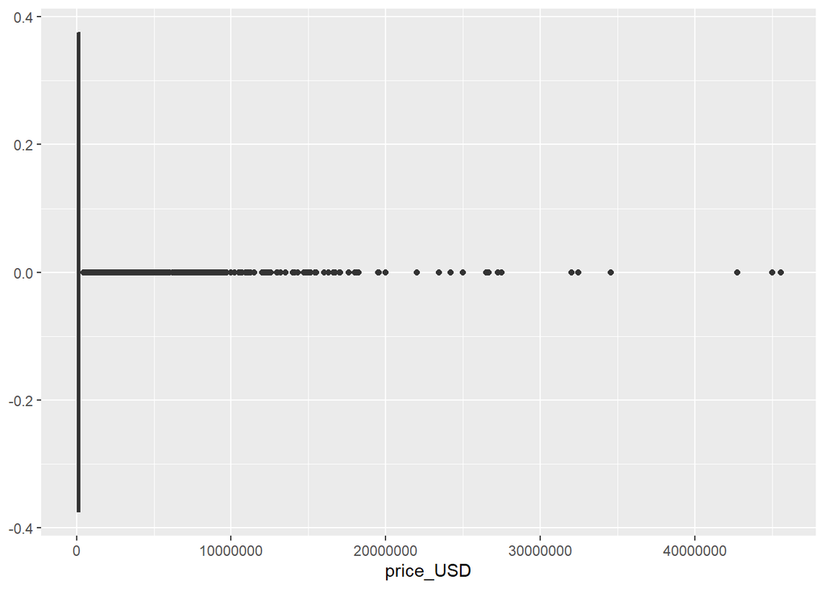

```r
#boxplot of the dependent variable

ggplot(ar, aes(x = price_USD)) +
  geom_boxplot()
```

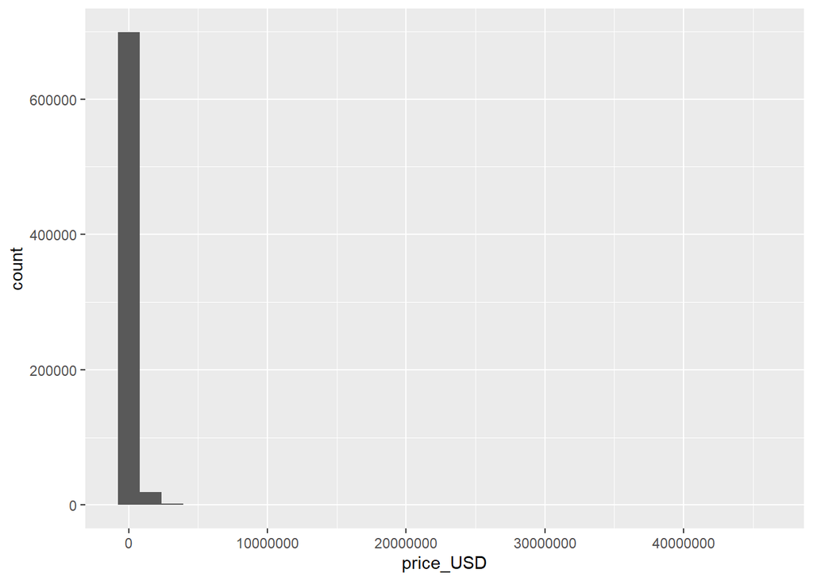

```r
ggplot(ar, aes(price_USD)) +
  geom_histogram()
```

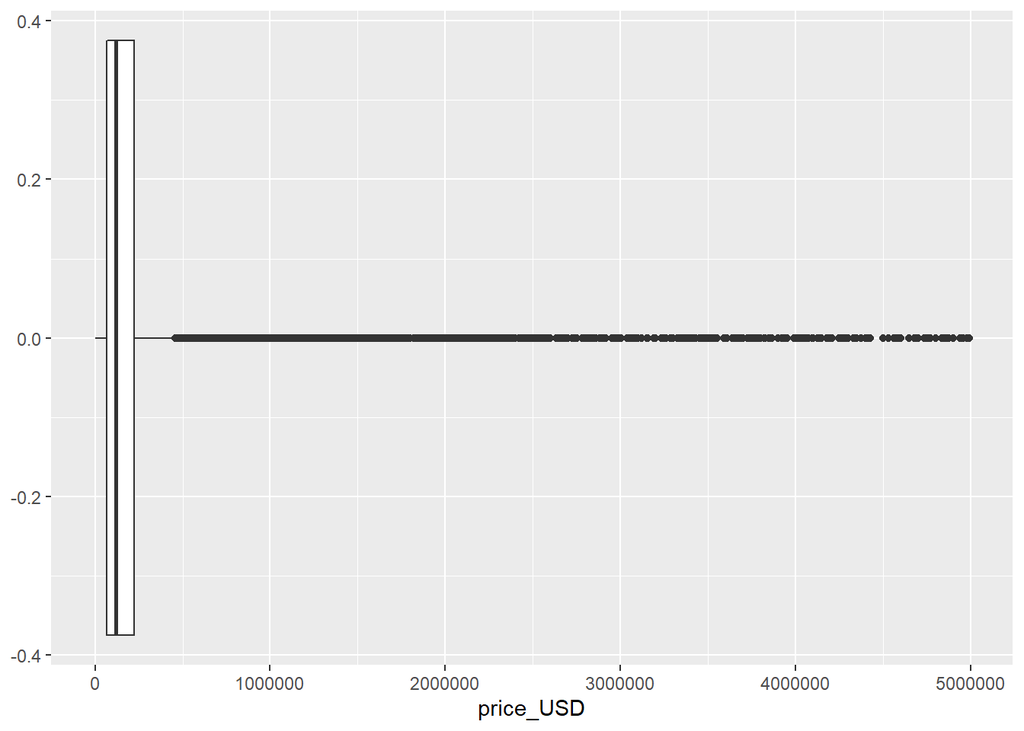

```r
# filtering data
ar = ar %>% filter(price_USD <5000000)

ar %>% ggplot(aes(x = price_USD)) +
  geom_boxplot()
```

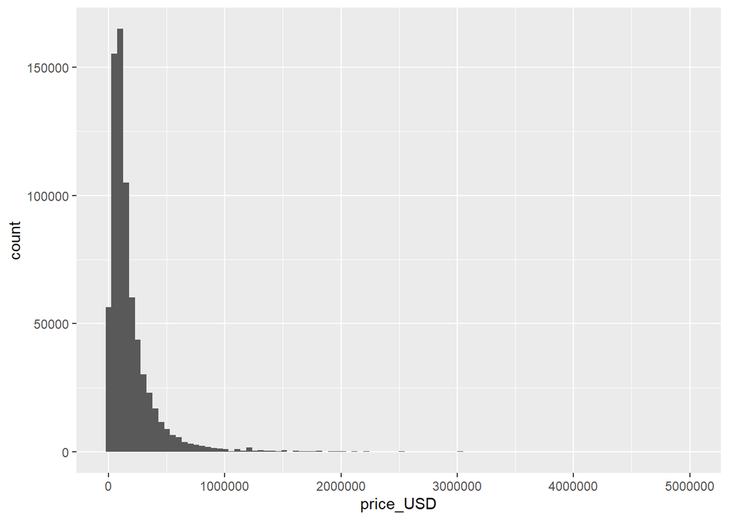

```r
# distribution of the dependent variable
ar %>% ggplot(aes(x = price_USD)) +
  geom_histogram(bins = 100)
```

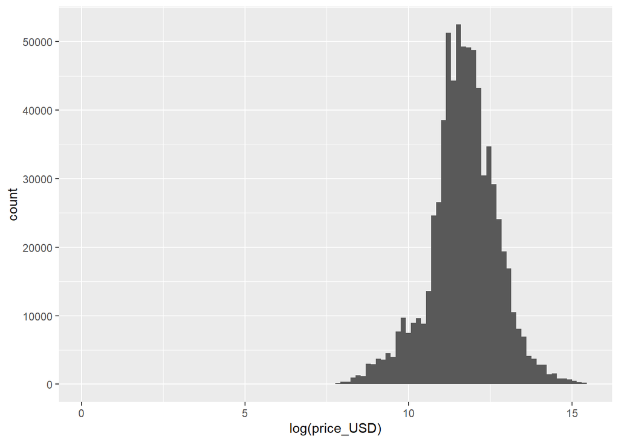

```r
#clearly right-skewed distribution.

ggplot(ar,
       aes(x = log(price_USD ))) +
  geom_histogram(
                 bins = 100)
```

```r
ar["price_log"] = log(ar$price_USD)

median(ar$price)
```

After log transformation our prices look symmetrically distributed.

## **Feature Selection and Imputing Missing Values**

Splitting data into train and test with the help of createDataPartition() function from caret package.

```r
library(caret)


#splitting data set into train and test.
set.seed(123)
splitting <- createDataPartition(ar$price_USD,
                                          p = 0.7,
                                          list = FALSE)

train = ar[splitting,]
test = ar[-splitting,]

# distribution of the target variable in both samples

summary(train$price_USD)
```

```
##    Min. 1st Qu.  Median    Mean 3rd Qu.    Max.
##       1   69000  120000  199104  225000 4990000
```

```r
summary(test$price_USD)
```

```
##    Min. 1st Qu.  Median    Mean 3rd Qu.    Max.
##      75   69000  120000  199374  225000 4980552
```

### **Numeric variables**

Correlation between target and numeric variables and relations between each other.

```r
library(corrr)
#correlation with target value
train %>% select( rooms, bedrooms, bathrooms, surface_covered, surface_total, price_USD, month, day) %>%
 correlate() %>% focus(price_USD)
```

```
##
## Correlation method: 'pearson'
## Missing treated using: 'pairwise.complete.obs'
```

```
## # A tibble: 7 x 2
##   term            price_USD
##   <chr>               <dbl>
## 1 rooms              0.346
## 2 bedrooms           0.275
## 3 bathrooms          0.576
## 4 surface_covered    0.0159
## 5 surface_total      0.0870
## 6 month              0.0534
## 7 day                0.0159
```

```r
train %>% select(rooms, bedrooms, bathrooms, surface_total, price_USD) %>%
  correlate()
```

```
##
## Correlation method: 'pearson'
## Missing treated using: 'pairwise.complete.obs'
```

```
## # A tibble: 5 x 6
##   term            rooms bedrooms bathrooms surface_total price_USD
##   <chr>           <dbl>    <dbl>     <dbl>         <dbl>     <dbl>
## 1 rooms         NA        0.688     0.613         0.0665    0.346
## 2 bedrooms       0.688   NA         0.551         0.0832    0.275
## 3 bathrooms      0.613    0.551    NA             0.0846    0.576
## 4 surface_total  0.0665   0.0832    0.0846       NA         0.0870
## 5 price_USD      0.346    0.275     0.576         0.0870   NA
```

```r
# missing values in percentage
sum(is.na(ar$rooms))/nrow(ar)
```

```
## [1] 0.5245857
```

```r
sum(is.na(ar$bedrooms))/nrow(ar)
```

```
## [1] 0.6337437
```

```r
sum(is.na(ar$bathrooms))/nrow(ar)
```

```
## [1] 0.2384115
```

```r
# removing columns
train = train %>% select(-surface_covered, -day, -bedrooms)
test = test %>% select(-surface_covered, -day, -bedrooms)

numeric_vars <-
  sapply(ar, is.numeric) %>%
  which() %>%
  names()
```

Surface_total partially consist information from surfaced_covered variable and due to poor correlation of surface_covered variable with dependent variable, it can be removed from data. Following step would be checking correlation between independent variables. Rooms, bedrooms and bathrooms are correlated between each other. Due to the fact that around 63.3743708% of bedrooms column values are missing, it will be removed from the data. Day will be removed from data due to small correlation with target variable.

### **Categorical variables**

Correlation between target and categorical variables and relations between each other.

```r
ar_categorical_vars =
  sapply(ar, is.factor) %>%
  which() %>%
  names()

property_anova = aov(train$price_USD ~ train$property_type)
summary(property_anova)[[1]][1, 4:5]
```

```
##                     F value                Pr(>F)
## train$property_type  2146.7 < 0.00000000000000022 ***
## ---
## Signif. codes:  0 '***' 0.001 '**' 0.01 '*' 0.05 '.' 0.1 ' ' 1
```

```r
l2_anova = aov(train$price_USD ~ train$l2)
summary(l2_anova)[[1]][1, 4:5]
```

```
##             F value                Pr(>F)
## train$l2     1042.3 < 0.00000000000000022 ***
## ---
## Signif. codes:  0 '***' 0.001 '**' 0.01 '*' 0.05 '.' 0.1 ' ' 1
```

Very low p-values for both tests show that we can reject null hypothesis saying that variables property_type and l2 do not have any impact on dependent variable hence mentioned variables will be included to our model.

## **Near to zero Variance**

```r
train_2 = train %>% select( -operation_type)

near_zero = nearZeroVar(train_2,
                        saveMetrics = TRUE)

near_zero %>% arrange(-zeroVar, -nzv)
```

```
##               freqRatio percentUnique zeroVar   nzv
## l2             1.266448   0.005551216   FALSE FALSE
## rooms          1.015636   0.006740762   FALSE FALSE
## bathrooms      2.231655   0.003965154   FALSE FALSE
## surface_total  1.316284   0.715908595   FALSE FALSE
## property_type  1.149975   0.001982577   FALSE FALSE
## month          1.033834   0.002379093   FALSE FALSE
## price_USD      1.160146   2.920930860   FALSE FALSE
## price_log      1.160146   2.920930860   FALSE FALSE
```

Due to the results none of the variables have zero or near to zero variance.

## **Missing values**

We still have missing values for the variable that could have impact on prices of the properties. For bathroom column we have 171790 missing values and for rooms variable we have 377996 missing values. Before deciding which method to use we’d tried to use prediction mean method from mice package but this method is very time consuming for large datasets. Finally, missing values will be imputed by the average values depending on the property type.

```r
# calculating averages
average_rooms <- train %>%
    filter(!is.na(rooms)) %>%
    group_by(property_type) %>%
    summarise(average_room = round(mean(rooms, na.rm = T)))

average_bathrooms <- train %>%
   filter(!is.na(bathrooms)) %>%
     group_by(property_type) %>%
     summarise(average_bathroom = round(mean(bathrooms, na.rm = T)))

average_surface = train %>%
    filter(!is.na(surface_total)) %>%
    group_by(property_type) %>%
    summarise(average_surface = round(mean(surface_total, na.rm = T)))

# merging averages with train set and filling missing values
train = merge(average_rooms, train)
train = merge(average_bathrooms, train)
train = merge(average_surface, train)


train = train %>% mutate(rooms = ifelse(is.na(rooms), average_room, rooms),
                         bathrooms = ifelse(is.na(bathrooms), average_bathroom, bathrooms),
                         surface_total = ifelse(is.na(surface_total), average_surface, surface_total)) %>%
  select(-average_bathroom, -average_room, -average_surface, -operation_type)


# merging averages with test set and filling missing values
test = merge(average_rooms, test)
test = merge(average_bathrooms, test)
test = merge(average_surface, test)

test = test %>% mutate(rooms = ifelse(is.na(rooms), average_room, rooms),
                         bathrooms = ifelse(is.na(bathrooms), average_bathroom, bathrooms),
                         surface_total = ifelse(is.na(surface_total), average_surface, surface_total)) %>%
  select(-average_bathroom, -average_room, -average_surface, -operation_type)
```

## **Linear Regression**

```r
ar_ln <- lm(price_log ~  month + property_type + l2 + rooms +bathrooms + surface_total,
                 data = train)

summary(ar_ln )
```

```
##
## Call:
## lm(formula = price_log ~ month + property_type + l2 + rooms +
##     bathrooms + surface_total, data = train)
##
## Residuals:
##      Min       1Q   Median       3Q      Max
## -11.0692  -0.3719   0.0064   0.4026   5.5549
##
## Coefficients:
##                                      Estimate    Std. Error  t value
## (Intercept)                     11.0831906362  0.0065736353 1686.006
## month                            0.0057664412  0.0003792394   15.205
## property_typeCasa de campo      -0.0256932443  0.0274117606   -0.937
## property_typeCochera            -1.5582514411  0.0118678669 -131.300
## property_typeDepÃ³sito           0.8868214304  0.0172513662   51.406
## property_typeDepartamento        0.0081750502  0.0040980176    1.995
## property_typeLocal comercial     0.0905288115  0.0088920349   10.181
## property_typeLote               -0.7967071642  0.0051871722 -153.592
## property_typeOficina            -0.1189068155  0.0103042493  -11.540
## property_typeOtro               -0.3226895256  0.0044556380  -72.423
## property_typePH                 -0.1919316381  0.0066470409  -28.875
## l2Bs.As. G.B.A. Zona Oeste      -0.2347428435  0.0050514756  -46.470
## l2Bs.As. G.B.A. Zona Sur        -0.2771224799  0.0045900175  -60.375
## l2Buenos Aires Costa AtlÃ¡ntica -0.3643037709  0.0044603456  -81.676
## l2Buenos Aires Interior         -0.4418455774  0.0082540330  -53.531
## l2CÃ³rdoba                      -0.6499007164  0.0059320607 -109.557
## l2Capital Federal                0.1258482114  0.0041486487   30.335
## l2Catamarca                     -0.2914737880  0.0752892916   -3.871
## l2Chaco                         -1.1995094152  0.0446197960  -26.883
## l2Chubut                        -0.3116331773  0.0421412116   -7.395
## l2Corrientes                    -0.4797355531  0.0427382991  -11.225
## l2Entre RÃos                   -0.7021744462  0.0174912962  -40.144
## l2Formosa                       -0.7426330285  0.1200542161   -6.186
## l2Jujuy                         -0.8500570495  0.0511755508  -16.611
## l2La Pampa                      -0.6497210582  0.0546431237  -11.890
## l2La Rioja                      -0.7421614877  0.1365582486   -5.435
## l2Mendoza                       -0.9127286610  0.0113268086  -80.581
## l2Misiones                      -1.2207523411  0.0169233624  -72.134
## l2NeuquÃ©n                      -0.4877887385  0.0129514669  -37.663
```

[output cut: 45 more lines]

```
## l2San Luis                      < 0.0000000000000002 ***
## l2Santa Cruz                    < 0.0000000000000002 ***
## l2Santa Fe                      < 0.0000000000000002 ***
## l2Santiago Del Estero           0.000000000000000434 ***
## l2Tierra Del Fuego              0.000000000680615642 ***
## l2TucumÃ¡n                      < 0.0000000000000002 ***
## rooms                           < 0.0000000000000002 ***
## bathrooms                       < 0.0000000000000002 ***
## surface_total                   < 0.0000000000000002 ***
## ---
## Signif. codes:  0 '***' 0.001 '**' 0.01 '*' 0.05 '.' 0.1 ' ' 1
##
## Residual standard error: 0.796 on 504353 degrees of freedom
## Multiple R-squared:  0.4002, Adjusted R-squared:  0.4001
## F-statistic:  8412 on 40 and 504353 DF,  p-value: < 0.00000000000000022
```

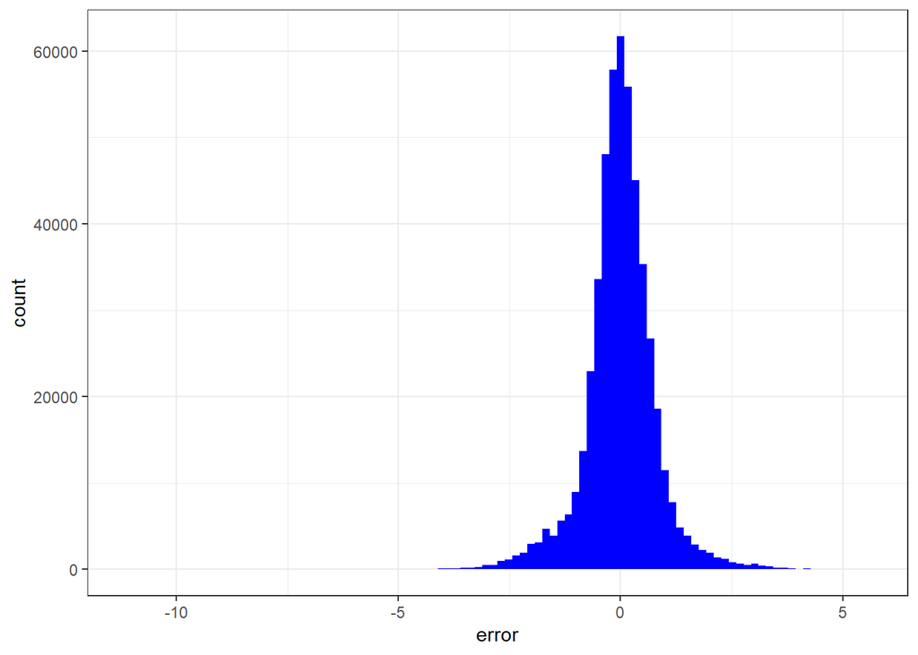

```r
#distribution fo the error terms

houses_predicted = predict(ar_ln)

# the distribution of errors

ggplot(data.frame(error = train$price_log - houses_predicted),
       aes(x = error)) +
  geom_histogram(fill = "blue",
                 bins = 100) +
  theme_bw()
```

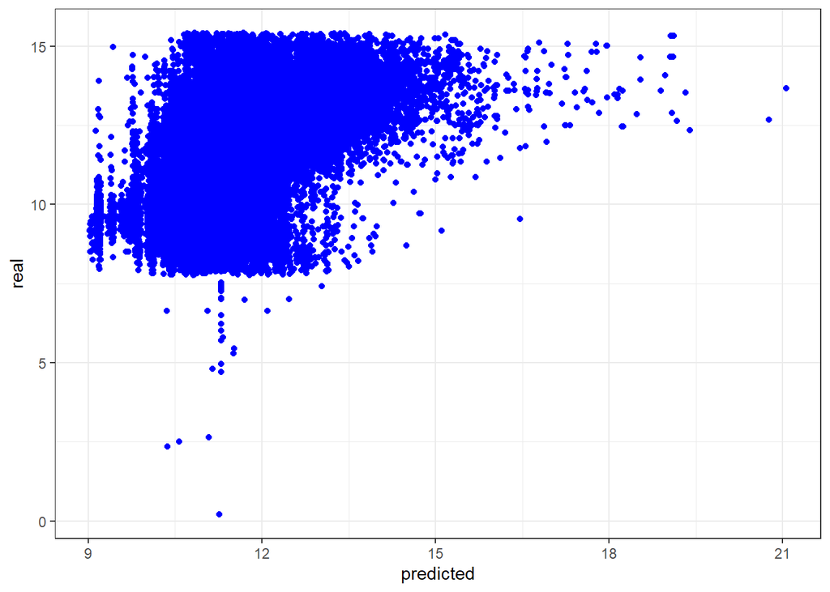

```r
# and plot real values against the predicted

ggplot(data.frame(real = train$price_log,
                  predicted = houses_predicted),
       aes(x = predicted,
           y = real)) +
  geom_point(col = "blue") +
  theme_bw()
```

```r
# check their correlation

cor(train$price_log,
    houses_predicted)
```

```
## [1] 0.6325957
```

```r
# We can see that deviation of error terms from zero is quite big, as some of them reaches -/+ 5. Scatter plot shows us that there is no linear relationship between predicted and real values and correlation between them is only 0.63.
```

We can see that deviation of error terms from zero is quite big, as some of them reaches -/+ 5. Scatter plot shows us that there is no linear relationship between predicted and real values and correlation between them is only 0.6325957.

## **Polynomial Regression**

After experimenting with different orders of polynomial function it was decided to show the result fr 3rd order, as later results did not change significantly.

```r
ar_pol <- lm(price_log ~ month + I(month^2)  + property_type + l2 + rooms + I(rooms^2) + I(bathrooms^2) + I(bathrooms^3) + surface_total + I(surface_total^3) + I(surface_total^2) + surface_total + bathrooms,
                 data = train)

summary(ar_pol )
```

```
##
## Call:
## lm(formula = price_log ~ month + I(month^2) + property_type +
##     l2 + rooms + I(rooms^2) + I(bathrooms^2) + I(bathrooms^3) +
##     surface_total + I(surface_total^3) + I(surface_total^2) +
##     surface_total + bathrooms, data = train)
##
## Residuals:
##      Min       1Q   Median       3Q      Max
## -10.9944  -0.3650   0.0040   0.3972   5.5456
##
## Coefficients:
##                                               Estimate             Std. Error
## (Intercept)                     10.6955038878908172961  0.0089796676675183602
## month                            0.0412989131780416366  0.0015234299847994176
## I(month^2)                      -0.0027741523276640511  0.0001163133847122970
## property_typeCasa de campo      -0.1367309436905199682  0.0276236134180916776
## property_typeCochera            -1.4140862496931059233  0.0120006174197817110
## property_typeDepÃ³sito           0.9484720611583726813  0.0173355277951733923
## property_typeDepartamento        0.0869358649135303085  0.0042156044805780066
## property_typeLocal comercial     0.1627946536889972318  0.0089635634614614081
## property_typeLote               -0.7894289831901986076  0.0055121635329044511
## property_typeOficina            -0.0628702812573554704  0.0102702174628310442
## property_typeOtro               -0.4534439419557564355  0.0075832765715846502
## property_typePH                 -0.1502484541871673684  0.0066358813653261822
## l2Bs.As. G.B.A. Zona Oeste      -0.2260960094184701619  0.0050176686072199855
## l2Bs.As. G.B.A. Zona Sur        -0.2681665056763191113  0.0045619551317538356
## l2Buenos Aires Costa AtlÃ¡ntica -0.3530821712136786306  0.0044330212855860241
## l2Buenos Aires Interior         -0.4378022197840362173  0.0081998053914979028
## l2CÃ³rdoba                      -0.6425534399475223424  0.0058923651083934393
## l2Capital Federal                0.1382290155130619647  0.0041241180923050659
## l2Catamarca                     -0.2970008727727111442  0.0747481047554987010
## l2Chaco                         -1.1836309957352340039  0.0442991828920190345
## l2Chubut                        -0.3013516970141610352  0.0418385886923367950
## l2Corrientes                    -0.4661952298834115549  0.0424310764296059531
## l2Entre RÃos                   -0.6909395242049627406  0.0173666375394721517
## l2Formosa                       -0.7288043157490861068  0.1191951874232831110
## l2Jujuy                         -0.8332240939266218893  0.0508085405414738719
## l2La Pampa                      -0.6532377856611594202  0.0542517086677631252
## l2La Rioja                      -0.7400692719335597580  0.1355764818418620510
```

[output cut: 59 more lines]

```
## l2TucumÃ¡n                       -50.122 < 0.0000000000000002 ***
## rooms                             94.833 < 0.0000000000000002 ***
## I(rooms^2)                       -46.761 < 0.0000000000000002 ***
## I(bathrooms^2)                   -14.165 < 0.0000000000000002 ***
## I(bathrooms^3)                    -3.869             0.000109 ***
## surface_total                     32.232 < 0.0000000000000002 ***
## I(surface_total^3)                15.213 < 0.0000000000000002 ***
## I(surface_total^2)               -19.560 < 0.0000000000000002 ***
## bathrooms                         98.067 < 0.0000000000000002 ***
## ---
## Signif. codes:  0 '***' 0.001 '**' 0.01 '*' 0.05 '.' 0.1 ' ' 1
##
## Residual standard error: 0.7903 on 504347 degrees of freedom
## Multiple R-squared:  0.4088, Adjusted R-squared:  0.4087
## F-statistic:  7581 on 46 and 504347 DF,  p-value: < 0.00000000000000022
```

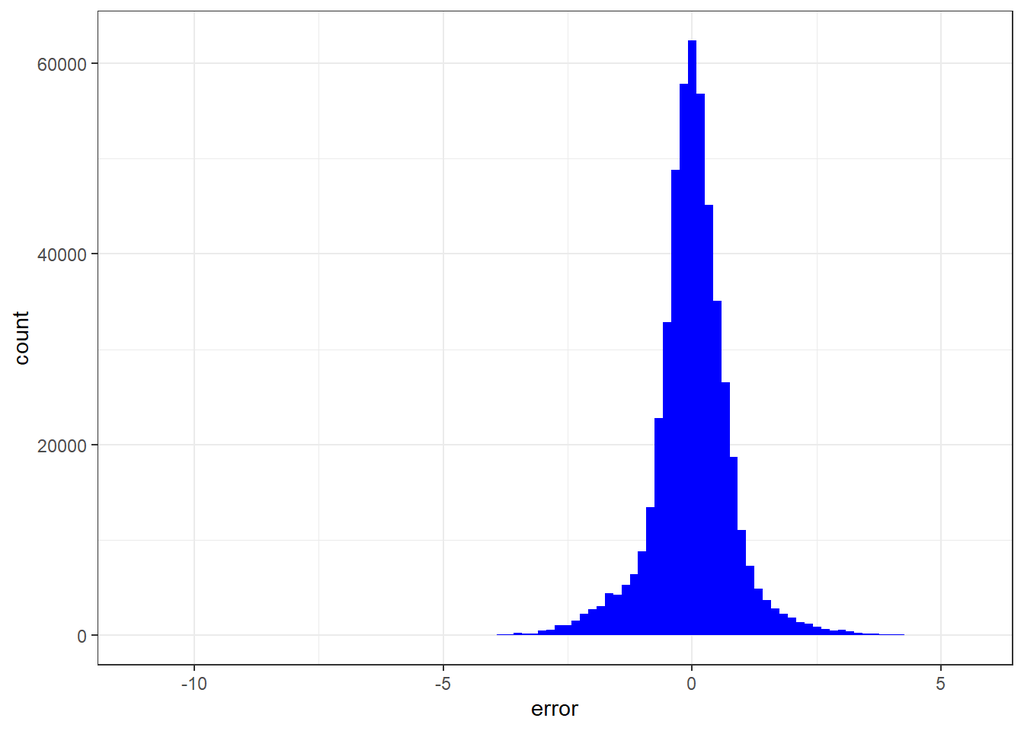

```r
#distribution for the error terms

houses_predicted = predict(ar_pol)

# and check the distribution of error

ggplot(data.frame(error = train$price_log - houses_predicted),
       aes(x = error)) +
  geom_histogram(fill = "blue",
                 bins = 100) +
  theme_bw()
```

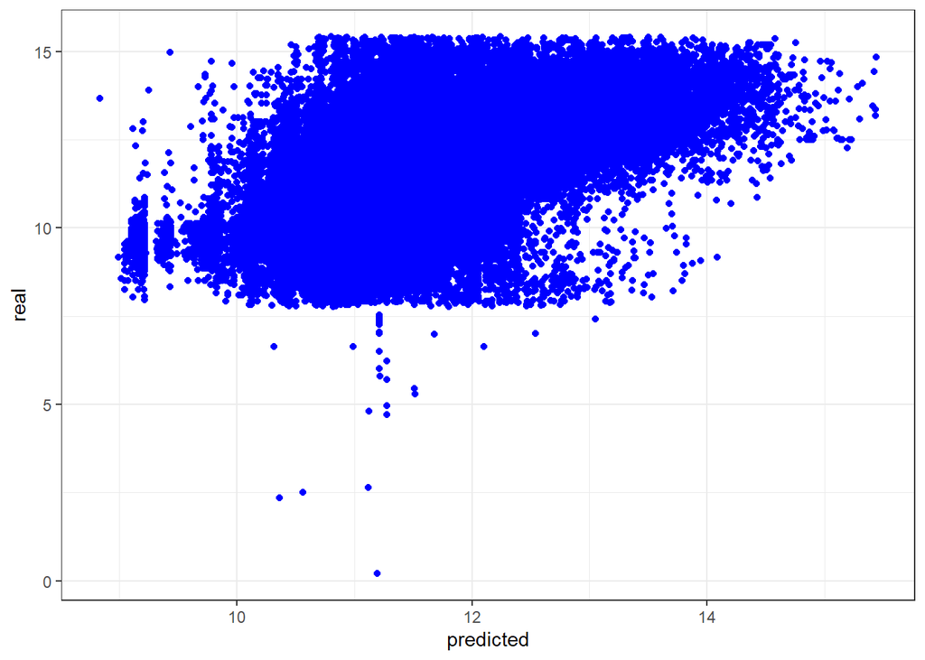

```r
# plot real values against the predicted

ggplot(data.frame(real = train$price_log,
                  predicted = houses_predicted),
       aes(x = predicted,
           y = real)) +
  geom_point(col = "blue") +
  theme_bw()
```

```r
# check their correlation

cor(train$price_log,
    houses_predicted)
```

```
## [1] 0.6393661
```

We can see that deviation of error terms from zero is slightly smaller comparing to linear model but still some of them reaches -/+ 5. Scatter plot shows us that there is no linear relationship between predicted and real values and correlation between them is 0.6393661.

## **Model validation**

```r
library(caret)
library(dplyr)

ctrl_cv5 = trainControl(method = "cv",
                          number = 5)


set.seed(123)

lm_train =
  train(price_log ~ month + I(month^2)  + property_type + l2 + rooms + I(rooms^2) + I(bathrooms^2) + I(bathrooms^3) + surface_total + I(surface_total^3) + I(surface_total^2) + surface_total + bathrooms,
        data = train,
        method = "lm",
        trControl = ctrl_cv5)

summary(lm_train)
```

```
##
## Call:
## lm(formula = .outcome ~ ., data = dat)
##
## Residuals:
##      Min       1Q   Median       3Q      Max
## -10.9944  -0.3650   0.0040   0.3972   5.5456
##
## Coefficients:
##                                                 Estimate             Std. Error
## (Intercept)                       10.6955038878908172961  0.0089796676675183602
## month                              0.0412989131780416366  0.0015234299847994176
## `I(month^2)`                      -0.0027741523276640511  0.0001163133847122970
## `property_typeCasa de campo`      -0.1367309436905199682  0.0276236134180916776
## property_typeCochera              -1.4140862496931059233  0.0120006174197817110
## property_typeDepÃ³sito             0.9484720611583726813  0.0173355277951733923
## property_typeDepartamento          0.0869358649135303085  0.0042156044805780066
## `property_typeLocal comercial`     0.1627946536889972318  0.0089635634614614081
## property_typeLote                 -0.7894289831901986076  0.0055121635329044511
## property_typeOficina              -0.0628702812573554704  0.0102702174628310442
## property_typeOtro                 -0.4534439419557564355  0.0075832765715846502
## property_typePH                   -0.1502484541871673684  0.0066358813653261822
## `l2Bs.As. G.B.A. Zona Oeste`      -0.2260960094184701619  0.0050176686072199855
## `l2Bs.As. G.B.A. Zona Sur`        -0.2681665056763191113  0.0045619551317538356
## `l2Buenos Aires Costa AtlÃ¡ntica` -0.3530821712136786306  0.0044330212855860241
## `l2Buenos Aires Interior`         -0.4378022197840362173  0.0081998053914979028
## l2CÃ³rdoba                        -0.6425534399475223424  0.0058923651083934393
## `l2Capital Federal`                0.1382290155130619647  0.0041241180923050659
## l2Catamarca                       -0.2970008727727111442  0.0747481047554987010
## l2Chaco                           -1.1836309957352340039  0.0442991828920190345
## l2Chubut                          -0.3013516970141610352  0.0418385886923367950
## l2Corrientes                      -0.4661952298834115549  0.0424310764296059531
## `l2Entre RÃos`                   -0.6909395242049627406  0.0173666375394721517
## l2Formosa                         -0.7288043157490861068  0.1191951874232831110
## l2Jujuy                           -0.8332240939266218893  0.0508085405414738719
## `l2La Pampa`                      -0.6532377856611594202  0.0542517086677631252
## `l2La Rioja`                      -0.7400692719335597580  0.1355764818418620510
## l2Mendoza                         -0.9081202772277310320  0.0112480239651128744
## l2Misiones                        -1.1986098823722843854  0.0168072931473151402
## `l2NeuquÃ©n`                      -0.4742105786810509871  0.0128610992323369006
```

[output cut: 56 more lines]

```
## `l2TucumÃ¡n`                       -50.122 < 0.0000000000000002 ***
## rooms                               94.833 < 0.0000000000000002 ***
## `I(rooms^2)`                       -46.761 < 0.0000000000000002 ***
## `I(bathrooms^2)`                   -14.165 < 0.0000000000000002 ***
## `I(bathrooms^3)`                    -3.869             0.000109 ***
## surface_total                       32.232 < 0.0000000000000002 ***
## `I(surface_total^3)`                15.213 < 0.0000000000000002 ***
## `I(surface_total^2)`               -19.560 < 0.0000000000000002 ***
## bathrooms                           98.067 < 0.0000000000000002 ***
## ---
## Signif. codes:  0 '***' 0.001 '**' 0.01 '*' 0.05 '.' 0.1 ' ' 1
##
## Residual standard error: 0.7903 on 504347 degrees of freedom
## Multiple R-squared:  0.4088, Adjusted R-squared:  0.4087
## F-statistic:  7581 on 46 and 504347 DF,  p-value: < 0.00000000000000022
```

```r
library(yardstick)
lm_fitted = predict(lm_train,
                     train)

mae(data = train, price_log, lm_fitted)
```

```
## # A tibble: 1 x 3
##   .metric .estimator .estimate
##   <chr>   <chr>          <dbl>
## 1 mae     standard       0.550
```

```r
rmse(data = train, price_log, lm_fitted)
```

```
## # A tibble: 1 x 3
##   .metric .estimator .estimate
##   <chr>   <chr>          <dbl>
## 1 rmse    standard       0.790
```

```r
lm_forecasts = predict(lm_train,
                        test)

mae(data = test, price_log, lm_forecasts)
```

```
## # A tibble: 1 x 3
##   .metric .estimator .estimate
##   <chr>   <chr>          <dbl>
## 1 mae     standard       0.554
```

```r
rmse(data = test, price_log, lm_forecasts)
```

```
## # A tibble: 1 x 3
##   .metric .estimator .estimate
##   <chr>   <chr>          <dbl>
## 1 rmse    standard       0.795
```

Values for fitted values are slightly better than for predictions.

Value of RMSE close to 1 indicates that our predicted values are far from observed one. On average the difference between observed and predicted price is 0.55 percentage points.

Based on above metrics we can conclude that polynomial model is not appropriate to predict prices.

## **Centering data**

```r
library(caret)
library(dplyr)

ctrl_cv5 = trainControl(method = "cv",
                          number = 5)


set.seed(123)

lm_train_centered =
  train(price_log ~ month + I(month^2)  + property_type + l2 + rooms + I(rooms^2) + I(bathrooms^2) + I(bathrooms^3) + surface_total +
          I(surface_total^3) + I(surface_total^2) + surface_total + bathrooms,
        data = train,
        method = "lm",
        preProcess=c('center'),
        trControl = ctrl_cv5)
```

```r
library(yardstick)

lm_fitted_centered = predict(lm_train_centered,
                     train)

mae(data = train, price_log, lm_fitted_centered)
```

```
## # A tibble: 1 x 3
##   .metric .estimator .estimate
##   <chr>   <chr>          <dbl>
## 1 mae     standard       0.550
```

```r
rmse(data = train, price_log, lm_fitted_centered)
```

```
## # A tibble: 1 x 3
##   .metric .estimator .estimate
##   <chr>   <chr>          <dbl>
## 1 rmse    standard       0.790
```

```r
lm_forecasts_centered = predict(lm_train_centered,
                        test)

mae(data = test, price_log, lm_forecasts_centered)
```

```
## # A tibble: 1 x 3
##   .metric .estimator .estimate
##   <chr>   <chr>          <dbl>
## 1 mae     standard       0.554
```

```r
rmse(data = test, price_log, lm_forecasts_centered)
```

```
## # A tibble: 1 x 3
##   .metric .estimator .estimate
##   <chr>   <chr>          <dbl>
## 1 rmse    standard       0.795
```

Centering the data did not change our results.

## **Ridge Regression**

```r
ctrl_cv5 = trainControl(method = "cv",
                         number = 5)

lambdas = 10^seq(2, -3, by = -.1)

parameters_ridge = expand.grid(alpha = 0,
                                lambda = lambdas)


set.seed(123456789)
houses_ridge = train(price_log ~  month + property_type + l2 + rooms +bathrooms + surface_total,
                      data = train,
                      method = "glmnet",
                      tuneGrid = parameters_ridge,
                      trControl = ctrl_cv5)

houses_ridge
```

```
## glmnet
##
## 504394 samples
##      6 predictor
##
## No pre-processing
## Resampling: Cross-Validated (5 fold)
## Summary of sample sizes: 403516, 403515, 403515, 403515, 403515
## Resampling results across tuning parameters:
##
##   lambda         RMSE       Rsquared   MAE
##     0.001000000  0.7967236  0.3995229  0.5566779
##     0.001258925  0.7967236  0.3995229  0.5566779
##     0.001584893  0.7967236  0.3995229  0.5566779
##     0.001995262  0.7967236  0.3995229  0.5566779
##     0.002511886  0.7967236  0.3995229  0.5566779
##     0.003162278  0.7967236  0.3995229  0.5566779
##     0.003981072  0.7967236  0.3995229  0.5566779
##     0.005011872  0.7967236  0.3995229  0.5566779
##     0.006309573  0.7967236  0.3995229  0.5566779
##     0.007943282  0.7967236  0.3995229  0.5566779
##     0.010000000  0.7967236  0.3995229  0.5566779
##     0.012589254  0.7967236  0.3995229  0.5566779
##     0.015848932  0.7967236  0.3995229  0.5566779
##     0.019952623  0.7967236  0.3995229  0.5566779
##     0.025118864  0.7967236  0.3995229  0.5566779
##     0.031622777  0.7967236  0.3995229  0.5566779
##     0.039810717  0.7967236  0.3995229  0.5566779
##     0.050118723  0.7969970  0.3993469  0.5569837
##     0.063095734  0.7974046  0.3990984  0.5574400
##     0.079432823  0.7979812  0.3987704  0.5580806
##     0.100000000  0.7987938  0.3983401  0.5589872
##     0.125892541  0.7999179  0.3977996  0.5602483
##     0.158489319  0.8014559  0.3971396  0.5619661
##     0.199526231  0.8035374  0.3963568  0.5642959
##     0.251188643  0.8063233  0.3954523  0.5673857
##     0.316227766  0.8100071  0.3944369  0.5714377
##     0.398107171  0.8147966  0.3933273  0.5767444
##     0.501187234  0.8209403  0.3921232  0.5834653
##     0.630957344  0.8286006  0.3908601  0.5916679
```

[output cut: 11 more lines]

```
##    10.000000000  0.9818091  0.3777135  0.7351835
##    12.589254118  0.9900103  0.3772118  0.7422679
##    15.848931925  0.9969381  0.3767945  0.7482189
##    19.952623150  1.0027167  0.3764517  0.7531795
##    25.118864315  1.0075116  0.3761689  0.7572837
##    31.622776602  1.0114274  0.3759413  0.7606245
##    39.810717055  1.0146421  0.3757543  0.7633645
##    50.118723363  1.0172275  0.3756060  0.7655669
##    63.095734448  1.0193377  0.3754842  0.7673623
##    79.432823472  1.0210158  0.3753889  0.7687887
##   100.000000000  1.0223822  0.3753103  0.7699491
##
## Tuning parameter 'alpha' was held constant at a value of 0
## RMSE was used to select the optimal model using the smallest value.
## The final values used for the model were alpha = 0 and lambda = 0.03981072.
```

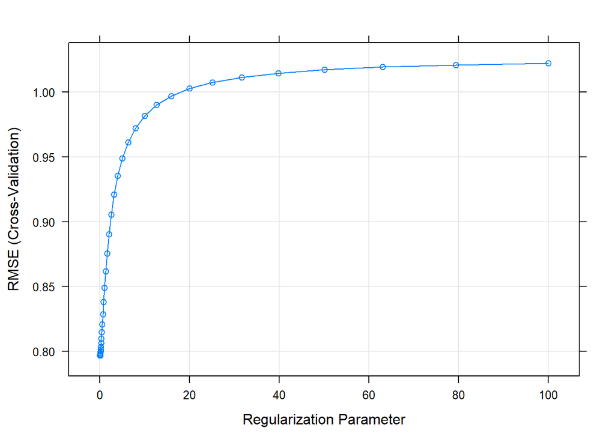

```r
plot(houses_ridge)
```

```r
houses_ridge$bestTune$lambda
```

```
## [1] 0.03981072
```

```r
ridge_fitted = predict(houses_ridge,
                     train)

mae(data = train, price_log, ridge_fitted)
```

```
## # A tibble: 1 x 3
##   .metric .estimator .estimate
##   <chr>   <chr>          <dbl>
## 1 mae     standard       0.557
```

```r
rmse(data = train, price_log, ridge_fitted)
```

```
## # A tibble: 1 x 3
##   .metric .estimator .estimate
##   <chr>   <chr>          <dbl>
## 1 rmse    standard       0.797
```

```r
ridge_forecasts = predict(houses_ridge,
                        test)

mae(data = test, price_log, ridge_forecasts)
```

```
## # A tibble: 1 x 3
##   .metric .estimator .estimate
##   <chr>   <chr>          <dbl>
## 1 mae     standard       0.560
```

```r
rmse(data = test, price_log,ridge_forecasts)
```

```
## # A tibble: 1 x 3
##   .metric .estimator .estimate
##   <chr>   <chr>          <dbl>
## 1 rmse    standard       0.802
```

From the plot we can conclude that the higher regularization parameter (lambda) the higher RMSE value we have. Best lambda which was used for estimating the final model is 0.039.

## **Lasso Regression**

```r
ctrl_cv5 = trainControl(method = "cv",
                         number = 5)

parameters_lasso = expand.grid(alpha = 1,
                                lambda = 10^seq(2, -3, by = -.1))


set.seed(123456789)

houses_lasso = train(price_log ~  month + property_type + l2 + rooms +bathrooms + surface_total,
                      data = train,
                      method = "glmnet",
                      tuneGrid = parameters_lasso,
                      trControl = ctrl_cv5)
houses_lasso
```

```
## glmnet
##
## 504394 samples
##      6 predictor
##
## No pre-processing
## Resampling: Cross-Validated (5 fold)
## Summary of sample sizes: 403516, 403515, 403515, 403515, 403515
## Resampling results across tuning parameters:
##
##   lambda         RMSE       Rsquared   MAE
##     0.001000000  0.7961765  0.3998858  0.5559945
##     0.001258925  0.7962017  0.3998559  0.5559879
##     0.001584893  0.7962427  0.3998072  0.5559874
##     0.001995262  0.7963079  0.3997291  0.5560008
##     0.002511886  0.7964103  0.3996057  0.5560370
##     0.003162278  0.7965709  0.3994114  0.5561159
##     0.003981072  0.7968193  0.3991088  0.5562596
##     0.005011872  0.7972049  0.3986344  0.5565143
##     0.006309573  0.7977925  0.3979043  0.5569385
##     0.007943282  0.7987016  0.3967532  0.5576336
##     0.010000000  0.8000876  0.3949615  0.5587500
##     0.012589254  0.8021246  0.3922738  0.5604485
##     0.015848932  0.8043678  0.3894540  0.5620942
##     0.019952623  0.8070386  0.3862254  0.5642049
##     0.025118864  0.8101812  0.3826536  0.5669171
##     0.031622777  0.8136267  0.3792484  0.5699997
##     0.039810717  0.8179718  0.3753589  0.5740740
##     0.050118723  0.8239589  0.3700750  0.5795611
##     0.063095734  0.8326262  0.3618832  0.5872580
##     0.079432823  0.8426574  0.3542535  0.5969455
##     0.100000000  0.8565034  0.3433592  0.6105507
##     0.125892541  0.8760002  0.3252024  0.6292764
##     0.158489319  0.8999789  0.3031700  0.6514570
##     0.199526231  0.9300669  0.2711634  0.6804705
##     0.251188643  0.9696400  0.1910431  0.7162729
##     0.316227766  0.9965673  0.1586651  0.7435710
##     0.398107171  1.0260988  0.1532633  0.7729191
##     0.501187234  1.0277361        NaN  0.7744901
##     0.630957344  1.0277361        NaN  0.7744901
```

[output cut: 11 more lines]

```
##    10.000000000  1.0277361        NaN  0.7744901
##    12.589254118  1.0277361        NaN  0.7744901
##    15.848931925  1.0277361        NaN  0.7744901
##    19.952623150  1.0277361        NaN  0.7744901
##    25.118864315  1.0277361        NaN  0.7744901
##    31.622776602  1.0277361        NaN  0.7744901
##    39.810717055  1.0277361        NaN  0.7744901
##    50.118723363  1.0277361        NaN  0.7744901
##    63.095734448  1.0277361        NaN  0.7744901
##    79.432823472  1.0277361        NaN  0.7744901
##   100.000000000  1.0277361        NaN  0.7744901
##
## Tuning parameter 'alpha' was held constant at a value of 1
## RMSE was used to select the optimal model using the smallest value.
## The final values used for the model were alpha = 1 and lambda = 0.001.
```

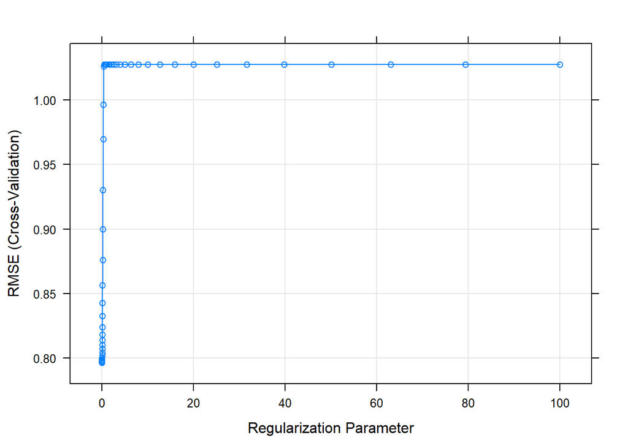

```r
plot(houses_lasso)
```

```r
houses_lasso$bestTune$lambda
```

```
## [1] 0.001
```

```r
lasso_fitted = predict(houses_lasso,
                     train)

mae(data = train, price_log, lasso_fitted)
```

```
## # A tibble: 1 x 3
##   .metric .estimator .estimate
##   <chr>   <chr>          <dbl>
## 1 mae     standard       0.556
```

```r
rmse(data = train, price_log, lasso_fitted)
```

```
## # A tibble: 1 x 3
##   .metric .estimator .estimate
##   <chr>   <chr>          <dbl>
## 1 rmse    standard       0.796
```

```r
lasso_forecasts = predict(houses_ridge,
                        test)

mae(data = test, price_log, lasso_forecasts)
```

```
## # A tibble: 1 x 3
##   .metric .estimator .estimate
##   <chr>   <chr>          <dbl>
## 1 mae     standard       0.560
```

```r
rmse(data = test, price_log,lasso_forecasts)
```

```
## # A tibble: 1 x 3
##   .metric .estimator .estimate
##   <chr>   <chr>          <dbl>
## 1 rmse    standard       0.802
```

For lasso regression RMSE grows drastically for high regularization parameter (lambda). Best lambda which was finally chosen is 0.001.

To sum up, both lasso and ridge regressions did not improve our predictions, as RMSE is quite high for both methods.

## **Decision tree**

```r
library(parsnip)
library(yardstick)


ctrl_cv10 = trainControl(method = "repeatedcv",
                           number = 5,
                           repeats = 3)

set.seed(123)
parameters_cp = data.frame(cp = c(0.1, 0.01, 0.001, 0.0001, 0.2, 1, 0.8, 1.5))

decisiontree_model =
  train(price_log ~  month + property_type + l2 + rooms +bathrooms + surface_total,
        data = train,
        method = "rpart",
        tuneGrid = parameters_cp,
        trControl = ctrl_cv10)
```

```r
tree_fitted = predict(decisiontree_model,
                     train)

mae(data = train, price_log, tree_fitted)
```

```
## # A tibble: 1 x 3
##   .metric .estimator .estimate
##   <chr>   <chr>          <dbl>
## 1 mae     standard       0.475
```

```r
rmse(data = train, price_log, tree_fitted)
```

```
## # A tibble: 1 x 3
##   .metric .estimator .estimate
##   <chr>   <chr>          <dbl>
## 1 rmse    standard       0.696
```

```r
tree_forecasts = predict(decisiontree_model,
                        test)

mae(data = test, price_log, tree_forecasts)
```

```
## # A tibble: 1 x 3
##   .metric .estimator .estimate
##   <chr>   <chr>          <dbl>
## 1 mae     standard       0.477
```

```r
rmse(data = test, price_log,tree_forecasts)
```

```
## # A tibble: 1 x 3
##   .metric .estimator .estimate
##   <chr>   <chr>          <dbl>
## 1 rmse    standard       0.701
```